# PS10: Geospatial Data

STAT 133

Author

**NoteGeneral Instructions**

- Download the template file `ps10.qmd` to answer the questions.
- Rename `ps10.qmd` to `ps10-first-last.qmd`, where `first` and `last` are your first and last names (e.g. `ps10-gaston-sanchez.qmd`).
- Download the file `countypres_2000-2020.csv` from bcourses and put it in the same directory as your qmd file. It is present in the description of this assignment and under files/problem-sets/ps10/
- Run `install.packages('usmap')` in the R *console*. You will need this package for a section of the assignment. **Do not put this in a code cell in the assignment.**
- Render your qmd file to an HTML file and submit both your qmd and HTML files to the corresponding assignment submission in bCourses.

# 1 Leaflet Map: Long Storms Data

We’ll use the `storms` data from `dplyr` that was used in lecture to get practice with leaflet maps as well as with `lubridate` durations. Start by using `head` to recall the structure of the `storms` data.

```r
# your code here
head(storms)
```

```
# A tibble: 6 × 13
  name   year month   day  hour   lat  long status       category  wind pressure
  <chr> <dbl> <dbl> <int> <dbl> <dbl> <dbl> <fct>           <dbl> <int>    <int>
1 Amy    1975     6    27     0  27.5 -79   tropical de…       NA    25     1013
2 Amy    1975     6    27     6  28.5 -79   tropical de…       NA    25     1013
3 Amy    1975     6    27    12  29.5 -79   tropical de…       NA    25     1013
4 Amy    1975     6    27    18  30.5 -79   tropical de…       NA    25     1013
5 Amy    1975     6    28     0  31.5 -78.8 tropical de…       NA    25     1012
6 Amy    1975     6    28     6  32.4 -78.7 tropical de…       NA    25     1012
# ℹ 2 more variables: tropicalstorm_force_diameter <int>,
#   hurricane_force_diameter <int>
```

## 1.1 Filtering Data

### 1.1.1 Combine Date and Time Information

In this dataset, the date and time variables are split into separate columns. Use the `make_datetime()` function inside `mutate` to create a new column that is a single datetime object. (Use `help(make_datetime)` in the R console to learn about this function)

```r
# your code here
storms <- storms |>
  mutate(
    dt = make_datetime(
      year = storms$year,
      month = storms$month,
      day = storms$day,
      hour = storms$hour
      )
  )

head(storms)
```

```
# A tibble: 6 × 14
  name   year month   day  hour   lat  long status       category  wind pressure
  <chr> <dbl> <dbl> <int> <dbl> <dbl> <dbl> <fct>           <dbl> <int>    <int>
1 Amy    1975     6    27     0  27.5 -79   tropical de…       NA    25     1013
2 Amy    1975     6    27     6  28.5 -79   tropical de…       NA    25     1013
3 Amy    1975     6    27    12  29.5 -79   tropical de…       NA    25     1013
4 Amy    1975     6    27    18  30.5 -79   tropical de…       NA    25     1013
5 Amy    1975     6    28     0  31.5 -78.8 tropical de…       NA    25     1012
6 Amy    1975     6    28     6  32.4 -78.7 tropical de…       NA    25     1012
# ℹ 3 more variables: tropicalstorm_force_diameter <int>,
#   hurricane_force_diameter <int>, dt <dttm>
```

### 1.1.2 Find Long Duration Storms

Now, for our purposes, we’re interested in the number of storms that lasted longer than three weeks.

```r
# your code here
long_storms <- storms |>
  group_by(name, year) |>
  summarise(duration = last(dt) - first(dt)) |>
  filter(duration >= 1814400)
long_storms
```

```
# A tibble: 7 × 3
# Groups:   name [7]
  name      year duration
  <chr>    <dbl> <drtn>
1 Alberto   2000 1857600 secs
2 Ivan      2004 1857600 secs
3 Jose      2017 1814400 secs
4 Kyle      2002 1879200 secs
5 Leslie    2018 1900800 secs
6 Nadine    2012 2052000 secs
7 Paulette  2020 1857600 secs
```

### 1.1.3 Merge Two Tables

```r
# your code here
storms <- merge(long_storms, storms, by = 'name')
head(storms)
```

```
     name year.x     duration year.y month day hour  lat  long         status
1 Alberto   2000 1857600 secs   2012     5  22   12 32.5 -74.7      other low
2 Alberto   2000 1857600 secs   2000     8   4   18 12.7 -25.2 tropical storm
3 Alberto   2000 1857600 secs   2012     5  19   18 32.3 -77.6 tropical storm
4 Alberto   2000 1857600 secs   2000     8  11   12 32.2 -58.6      hurricane
5 Alberto   2000 1857600 secs   2012     5  22    0 30.7 -77.1 tropical storm
6 Alberto   2000 1857600 secs   2012     5  21   18 30.5 -78.3 tropical storm
  category wind pressure tropicalstorm_force_diameter hurricane_force_diameter
1       NA   30     1008                            0                        0
2       NA   40     1002                           NA                       NA
3       NA   45      997                           70                        0
4        1   80      976                           NA                       NA
5       NA   35     1007                           40                        0
6       NA   35     1006                           70                        0
                   dt
1 2012-05-22 12:00:00
2 2000-08-04 18:00:00
3 2012-05-19 18:00:00
4 2000-08-11 12:00:00
5 2012-05-22 00:00:00
6 2012-05-21 18:00:00
```

## 1.2 Make Leaflet Maps

### 1.2.1 Basic Map

Let’s start by making a basic leaflet map by passing the data from the previous part to `leaflet`, then using `addProviderTiles("CartoDB.Positron")` and `addCircleMarkers`. Experiment with the `radius`, `color`, `stroke`, and `fillOpacity` inputs to `addCircleMarkers`.

```r
# your code here
leaflet(data = storms) |>
  addProviderTiles("CartoDB.Positron") |>
  addCircleMarkers(
    radius = 3,
    color = "blue",
    stroke = TRUE,
    fillOpacity = 0.6
  )
```

```
Assuming "long" and "lat" are longitude and latitude, respectively
```

[interactive chart not shown]

### 1.2.2 Map Including Category Level

```r
# your code here
leaflet(data = storms) |>
  addProviderTiles("CartoDB.Positron") |>
  addCircleMarkers(
    radius = 3,
    color = "blue",
    stroke = TRUE,
    fillOpacity = 0.6
  )
```

```
Assuming "long" and "lat" are longitude and latitude, respectively
```

[interactive chart not shown]

### 1.2.3 Color By Storms

Create a color pallet and replicate the same plot as before, but now color the points based on the name of the storm. Add a legend as well.

```r
# your code here
pal <- colorFactor(
  palette = rainbow(8),
  domain = storms$name)

leaflet(data = storms) |>
  addProviderTiles("CartoDB.Positron") |>
  addCircleMarkers(
    radius = 1,
    color = ~pal(name),
    stroke = TRUE,
    fillOpacity = 0.6
  ) |>
    addLegend(
    position = "bottomleft",
    pal = pal,
    values = ~name,
    title = "Storm name")
```

```
Assuming "long" and "lat" are longitude and latitude, respectively
```

[interactive chart not shown]

### 1.2.4 Map with Popup

Lastly, copy your code from the previous section and add a `popup` in `addCircleMarkers` that shows the `datetime` of the storm.

```r
# your code here
pal <- colorFactor(
  palette = rainbow(8),
  domain = storms$name)

leaflet(data = storms) |>
  addProviderTiles("CartoDB.Positron") |>
  addCircleMarkers(
    radius = 1,
    color = ~pal(name),
    stroke = TRUE,
    fillOpacity = 0.6,
    popup = ~dt
  ) |>
    addLegend(
    position = "bottomleft",
    pal = pal,
    values = ~name,
    title = "Storm name")
```

```
Assuming "long" and "lat" are longitude and latitude, respectively
```

[interactive chart not shown]

# 2 Coropleth Map: US Election Data

## 2.1 Read and Manipulate Data

```r
# your code here
pres_results <- read_csv('countypres_2000-2020.csv')
```

Use `head()` to take a look at the dataset.

```r
# your code here
head(pres_results)
```

```
# A tibble: 6 × 12
   year state   state_po county_name county_fips office       candidate    party
  <dbl> <chr>   <chr>    <chr>             <dbl> <chr>        <chr>        <chr>
1  2000 ALABAMA AL       AUTAUGA            1001 US PRESIDENT AL GORE      DEMO…
2  2000 ALABAMA AL       AUTAUGA            1001 US PRESIDENT GEORGE W. B… REPU…
3  2000 ALABAMA AL       AUTAUGA            1001 US PRESIDENT RALPH NADER  GREEN
4  2000 ALABAMA AL       AUTAUGA            1001 US PRESIDENT OTHER        OTHER
5  2000 ALABAMA AL       BALDWIN            1003 US PRESIDENT AL GORE      DEMO…
6  2000 ALABAMA AL       BALDWIN            1003 US PRESIDENT GEORGE W. B… REPU…
# ℹ 4 more variables: candidatevotes <dbl>, totalvotes <dbl>, version <dbl>,
#   mode <chr>
```

Currently, the data is presented at the county level, we need to compute the total number of votes for each candidate by state, and determine the winner party.

- Group the data by `state_po` (The state postal code abbreviation: e.g. CA for California) and `party`,
- use `summarize()` to `sum` the number of `candidatevotes` of all the counties,
- use `slice_max()` to get only the `state_po` and `party` pairings that have the largest vote counts,
- then `select()` the `state_po` and `party` columns.
- Finally, use vote counts to find the winning party by state instead of by county. Assign this to the variable `state_by_party`.

```r
# your code here
state_by_party <- pres_results |>
  group_by(state_po, party) |>
  summarise(sum_votes = sum(candidatevotes)) |>
  slice_max(sum_votes) |>
  select(state_po, party)
```

Use `head()` or `slice_head()` to check `state_by_party`.

```r
# your code here
head(state_by_party)
```

```
# A tibble: 6 × 2
# Groups:   state_po [6]
  state_po party
  <chr>    <chr>
1 AK       REPUBLICAN
2 AL       REPUBLICAN
3 AR       REPUBLICAN
4 AZ       REPUBLICAN
5 CA       DEMOCRAT
6 CO       DEMOCRAT
```

## 2.2 Merging Data

Before we can use the dataset to make the election results map, we need to merge it with geospatial data from the `usmap` package. We can use an `inner_join()` on the output of `us_map()` and our `state_by_party` tibble.

```r
us_states <- inner_join(us_map(), state_by_party, by = c("abbr" = "state_po"))
```

## 2.3 Making Maps

The `us_map()` function gives us a simple feature collection that contains the geospatial data to graph the electoral votes map. To plot this map with `ggplot()` all you have to do is add a `geom_sf()` layer.

### 2.3.1 Basic Map

Let’s start with a basic graph of the choropleth map, plotting the tiles that correspond to each state. pass the `us_states` data to ggplot and add a `geom_sf()` layer

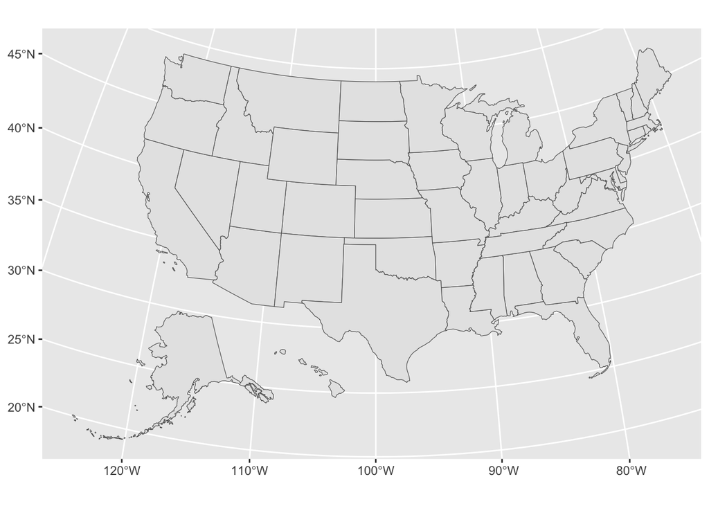

```r
# your code here
ggplot(data = us_states) +
  geom_sf()
```

### 2.3.2 Color by Party

Because the simple features data has been merged with `state_by_party`, we also have the winner `party` of each state. Therefore, we can *map* this variable to the `fill` aesthetic to color-code the tiles according to party. To make the colors align with the typical colors of the Democratic and Republican parties, add a `scale_fill_manual(values = c("#0077cc", "#cc2200"))` layer as well.

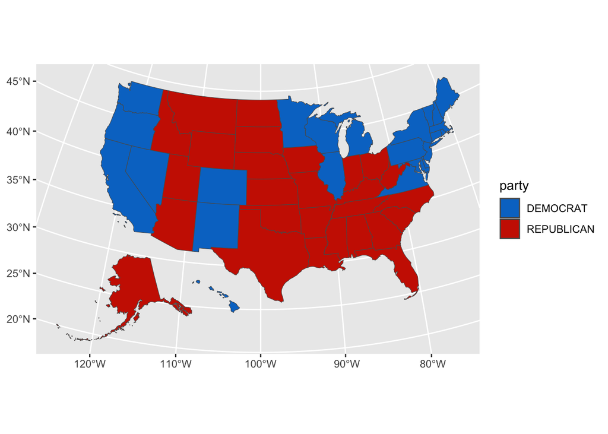

```r
# your code here
ggplot(data = us_states, aes(fill = party)) +
  geom_sf() +
  scale_fill_manual(values = c("#0077cc", "#cc2200"))
```

### 2.3.3 Label States

Add a `geom_sf_text()` layer with a mapping for `label = abbr`, which is the state name post office abbreviation. (You may want to mess with the `size` and `color` settings inside `geom_sf_text` in order for the labels to look nice on the colored backgrounds.)

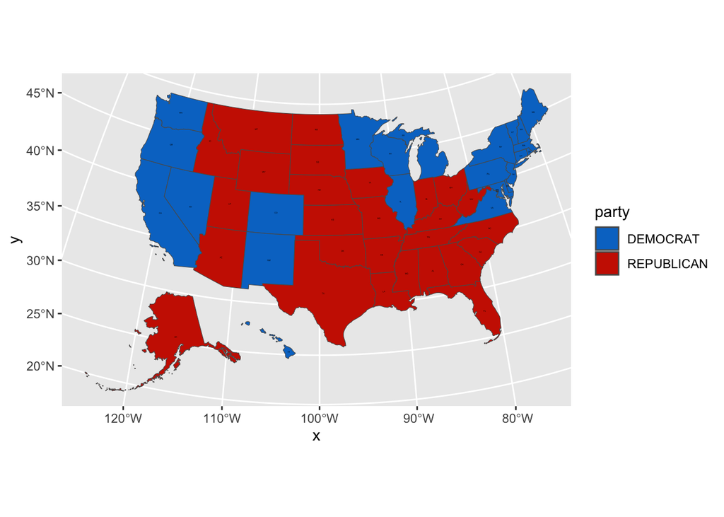

```r
# your code here
ggplot(data = us_states, aes(fill = party)) +
  geom_sf() +
  scale_fill_manual(values = c("#0077cc", "#cc2200")) +
  geom_sf_text(aes(label = abbr), size = 0.5)
```

### 2.3.4 Final Step

Add the `theme_void` layer to leave just the map without the axis or gridlines. (Not required, but you may also want to try and position the legend below the map and remove the title.)

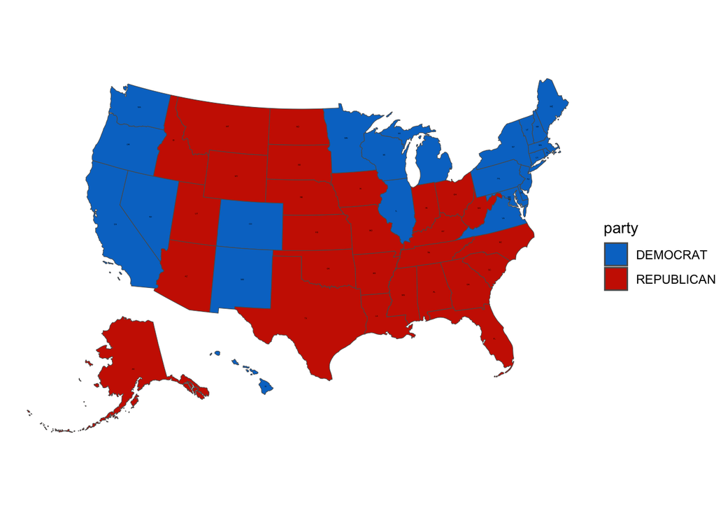

```r
# your code here
ggplot(data = us_states, aes(fill = party)) +
  geom_sf() +
  scale_fill_manual(values = c("#0077cc", "#cc2200")) +
  geom_sf_text(aes(label = abbr), size = 0.5) +
  theme_void()
```

## 2.4 Interactive maps with `ggiraph`

We can make the map interactive by using functions from `"ggiraph"`. In this case, the function `geom_sf_interactive()` allows us to display a *tooltip* feature when we hover over a particular state.

### 2.4.1 Basic Interactive Plot

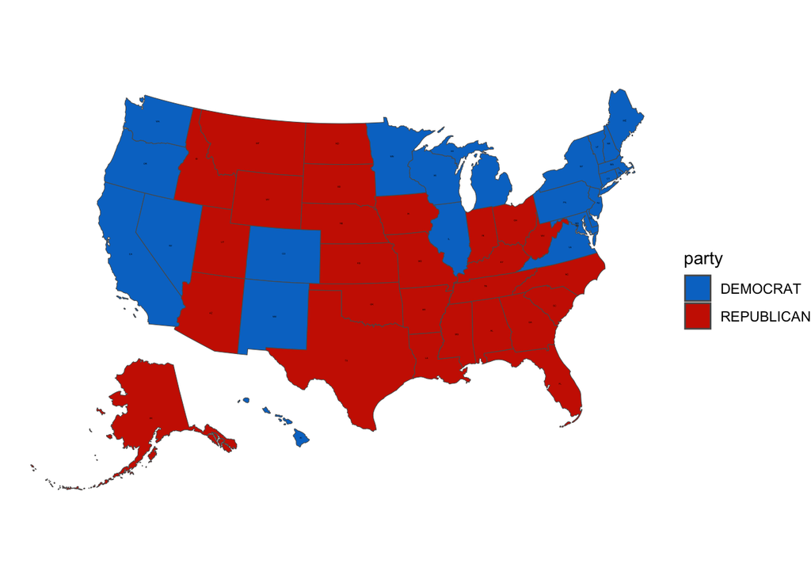

```r
# your code here

  ggplot(data = us_states, aes(fill = party)) +
  geom_sf_interactive(aes(tooltip = party)) +
  scale_fill_manual(values = c("#0077cc", "#cc2200")) +
  geom_sf_text(aes(label = abbr), size = 0.5) +
  theme_void()
```

### 2.4.2 Final Interactive Plot

It would be better to have a more informative message displayed by the *tooltip*, for instance, to be able to display the name of the state, as well as the proportion of votes for each party. This requires more data manipulation so that we know the proportion of votes that each party obtained in each state.

The following pipeline gives us such a table:

```r
state_by_party_prop = pres_results |>
  filter(year == 2020) |>
  group_by(state_po, party) |>
  summarize(votes = sum(candidatevotes)) |>
  mutate(prop = round(100 * votes / sum(votes), 2)) |>
  filter(party %in% c("DEMOCRAT", "REPUBLICAN")) |>
  select(state_po, party, prop) |>
  pivot_wider(names_from = party, values_from = prop) |>
  mutate(winner = ifelse(DEMOCRAT - REPUBLICAN > 0, "DEM", "REP"))
head(state_by_party_prop)
```

```
# A tibble: 6 × 4
# Groups:   state_po [6]
  state_po DEMOCRAT REPUBLICAN winner
  <chr>       <dbl>      <dbl> <chr>
1 AK           43.0       53.1 REP
2 AL           36.6       62.0 REP
3 AR           34.8       62.4 REP
4 AZ           49.4       49.1 DEM
5 CA           63.5       34.3 DEM
6 CO           55.4       41.9 DEM
```

As we’ve done before, the next step involves merging the `us_map()` geospatial data with the `state_by_party_prop` information. Use the code from the static plot as a guide and perform an `inner_join`.

```r
# your code here
new_map <- merge(us_map(), state_by_party_prop )
```

We can remake the interactive plot specifying a *tooltip* feature that displays the `full` name of the State from the `us_map()` data, together with the percentage of votes for both parties. Set a tooltip similarly to the previous part, but now using `tooltip = sprintf("%s\nDem: %s%%\nRep: %s%%", full, DEMOCRAT, REPUBLICAN)`.

[figure not shown]

```r
# your code here
  ggplot(data = new_map, aes(fill = winner)) +
  geom_sf_interactive(aes(tooltip = sprintf("%s\nDem: %s%%\nRep: %s%%", full, DEMOCRAT, REPUBLICAN))) +
  scale_fill_manual(values = c("#0077cc", "#cc2200")) +
  geom_sf_text(aes(label = abbr), size = 0.5) +
  theme_void()
```